# Experimental Evaluation of Software Systems

Tomas Kalibera and Jan Vitek

On modern computer systems, a program never runs for the same amount of time twice. Execution time is affected by the hardware, different runs may be loaded into different memory locations and experience different cache behaviors. Execution time is affected by the software, the operating system is working concurrently to the program and can interrupt it to perform house cleaning tasks or to let other programs execute. Execution time is affected by the way the program was built, modern compilers are non-deterministic as they compile the code of the program as it is running. Execution time is affected by the program’s inputs, some slight perturbations in the values given to the program can result in significant changes of performance. How can we answer questions such as *“Is program A faster than program B?”*

# Experimental design

We start by designing the experiment that captures the raw data. A design depends on the choice of *goals*, i.e. what the study should demonstrate, and on the intended *scope* of its conclusions, i.e. how broadly it can be applied.

## Builds, Runs and Iteration

We measure **iterations** of a system (e.g. time to process a request for a web server or compile a file for a compiler). A **run** of the system can have multiple iterations (e.g. a web server is started, it services a number of requests and then terminates). A **build** of the system refers to activities such as compilation and deployment of the system. One build can be used for multiple runs.

## Metrics

Typical metrics include: *responsiveness* (response time, latency, e.g. time between arrival of packets to the gateway and its successful delivery to the destination), *productivity* (throughput, speed, network bandwidth, e.g. number of transactions processed per second by application server), *utilization* (percentage of time a particular resource is at a given load level, e.g. percentage of time the CPU is not idle).

Metrics are either reported as **ratios** (e.g. measure of optimization such as speed-up, parallel speed-up, performance overhead) or as *absolute* values (eg. time of a system to boot and start accepting input, time of a garbage collection cycle, time to call a function).

## Data acquisition

Measurements are done either *internally* by instrumenting the system to keep track of time, or *externally* by relying on the operating system to give end-to-end time (as well as other measures such as memory, page faults, etc.). External measurement have to take into account the cost of starting the process, they should not be used for short running systems (say less than 100 ms).

## Configuration

*Sample configuration:* DaCapo 2006-10- MR2 [6] and 9.12-bach with their largest inputs. Trace data is collected on one iteration of the benchmark excluding start-up. Timings are recorded on uninstrumented runs where we strived to get at least 5 repetitions and 10 iterations; unless specified otherwise timings are the mean of these runs. We ran HotSpot 1.7.0 01 for Linux/x86 64, btrace 1.2.1 and ASM 3.3 on a 4.8GHz Intel Core i7, with 4 hardware threads (hyper-threading disabled) and 16GB of RAM. [Kalibera, ea. OOPSLA 2012]

A **configuration** describes how an experiment is conducted. For a software system, a configuration include the hardware on which the program is run (the processor model and the memory available), the way the system was built (the compiler, any relevant options), the way the software is run (any options passed to it and the inputs), and any other relevant characteristics of the execution environment (e.g. what other programs are running).

## Scope

SPEC for C, https://www.spec.org/cpu2006, and Java, https://www.spec.org/jvm2008, or Dacapo http://dacapobench.org.

Any non-trivial system has an infinite number of configurations.  
The scope of a study defines defines how broadly it may be applied. Are the result valid for single-core or do they also apply to multi-core processors? In practice, most performance studies are limited to a handful of hardware/software platforms and to standardized benchmarks with a handful of different inputs. When reporting on a study describe precisely the configurations used.

## Goals

Performance studies can be **ends-based**, that is to say they are designed to allow comparison between systems with similar functionalities, or **exploratory**, that is designed to understand a particular aspect of a system’s behavior. Goals impact what will be measured. End-based studies can be limited to a single measurement whereas explanatory studies benefit from measuring as many observable characteristics as is practical (for instance, cache misses, page faults, time spent in GC, compilation time, etc.) in the hope that some of those measurement will prove useful.

## Factors impacting execution time

**Fixed effects** and **random effects** can impact on execution time. Fixed effects include the *details of the algorithms* in the system under study (e.g. the optimizations performed by a compiler, or the details of a the indexing scheme used in a database system), *the input* (values passed into the system), *hw/sw environment* (CPU, OS, libraries, compiler optimizations, location in virtual memory). Random effects include location in physical memory, system load, scheduling, context switches, hw interrupts, randomized algorithms. Fixed effects depend on the configuration, randomize the aspects of the configuration that affect execution time. Random effects are modeled or summarized using statistical methods.

# Use-case 1: Java FOP

Our first use-case is an ends-based analysis of the Java `fop` benchmark. Fop belongs to the Dacapo benchmark suite; it takes an XSL-FO file, parses it and formats it, generating a PDF file as output. The metric here is execution time of one iteration.

## Acquisition

```
for I in `seq 1 100` ; do
    java -jar dacapo-9.12-bach.jar fop
done > fop.out 2>&1
```

Each run of the program performs one iteration of the benchmark.

## Import

The output of 100 runs are stored in `fop.out`. This reads the data into R and converts time from milliseconds to seconds.

```r
out <- readLines("fop.out")
rlines <-  grep("==== DaCapo .* in [0-9]+ msec.*", out, val=T)
timesms <-  as.numeric(gsub(".* in ([0-9]+) msec.*","\\1",rlines))
x <- timesms / 1000
```

We assume the observed times come from the same process, we thus have the same expectations about `x[1]` as about `x[2]`. In other words, we assume measured times to be (statistically) independent, the fact that `x[1]` is 2.75 doesn’t give us a clue what `x[2]` will be.

## Analysis

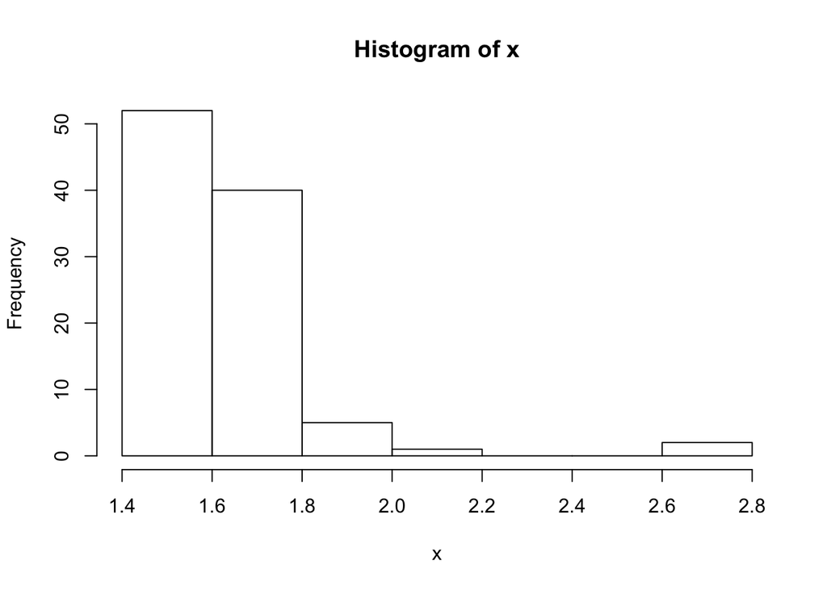

```r
hist(x, freq=T)
```

The data can be plotted with a **histogram**. By default, R chooses a granularity (a range), bins the observations and display the count for elements in each bin.

We can also ask R to compute probability densities (with `freq`) and plot the kernel density estimate with `density`.

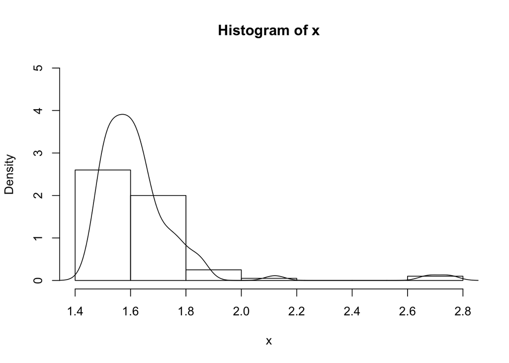

```r
hist(x, freq=F, ylim=c(0,5))
lines(density(x))
```

The width of each bin multiplied by its height give the probability of observation falling into this range.

A summary of the density function is the mean, here it is 1.63418.

The more observations we have the closer we should get to the actual mean.

If we plot the mean of the first `n` observation, with `n` ranging from 1 to `length(x)`. We see how the value converges towards `mean(x)`.

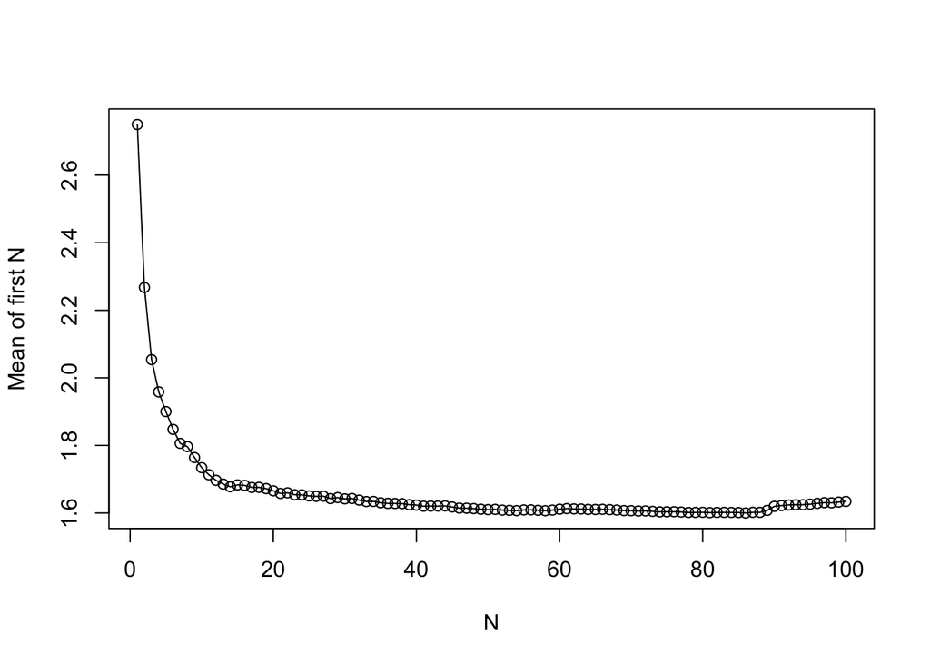

```r
plot(
    sapply(
      1:length(x),
      function(i) mean(x[1:i])),
    type="o",
    ylab="Mean of first N",
    xlab="N"
  )
```

Notice the “bump” towards the end, how can it be explained? Looking at the raw data with a **scatter plot**, reveals two outliers toward the end of the sequence of observations.

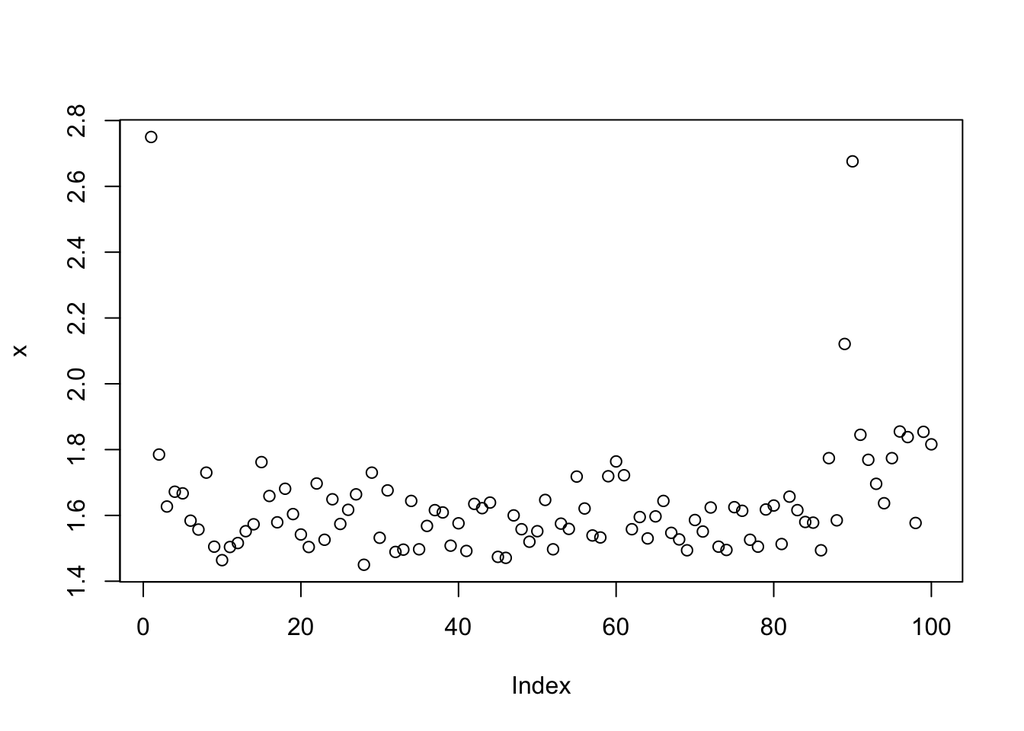

```r
plot(x)
```

It is fair to ask how close the of the observed data is to the true mean?

Given our assumptions of independence, lets simulate more experiments by re-sampling the measured values 100 times (with replacement).

The following plots the means of the simulations.

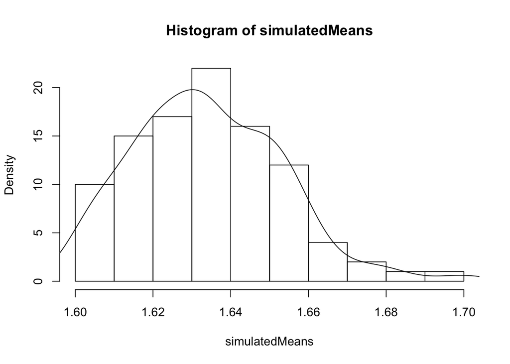

```r
simulatedMeans <- sapply(1:100,
    function(i)
    mean(sample(x, replace=T)))
hist(simulatedMeans, prob=T)
lines(density(simulatedMeans))
```

Lets find bounds that covers the true mean with a fixed confidence.

`quantile` is an R function that takes a vector of probabilities and returns values in the input data range.

```r
r <- quantile(simulatedMeans, probs=c(0.975, 0.025))
r
```

```
##    97.5%     2.5%
## 1.674871 1.603258
```

With 95% confidence, the true mean lies between 1.603 and 1.675.

As an alternative, we can use bootstrap and the `boot.ci` function to compute this.

```r
library(boot)
b <- boot(x, function(d, sel) mean(d[sel]), R=10000)
boot.ci(b, conf=0.95, type="perc")
```

```
## BOOTSTRAP CONFIDENCE INTERVAL CALCULATIONS
## Based on 10000 bootstrap replicates
##
## CALL :
## boot.ci(boot.out = b, conf = 0.95, type = "perc")
##
## Intervals :
## Level     Percentile
## 95%   ( 1.601,  1.676 )
## Calculations and Intervals on Original Scale
```

# Use-case 2: Dependence

Recall the assumption that our data was independent, this not always the case.

## Acquisition

Generate fifty dependent data point and fifty independent ones by sampling.

```r
d <- sapply(1:50, function(x)1/x)
i <- sample(d,replace=F)
```

`i` holds randomly reordered observations.

## Run charts

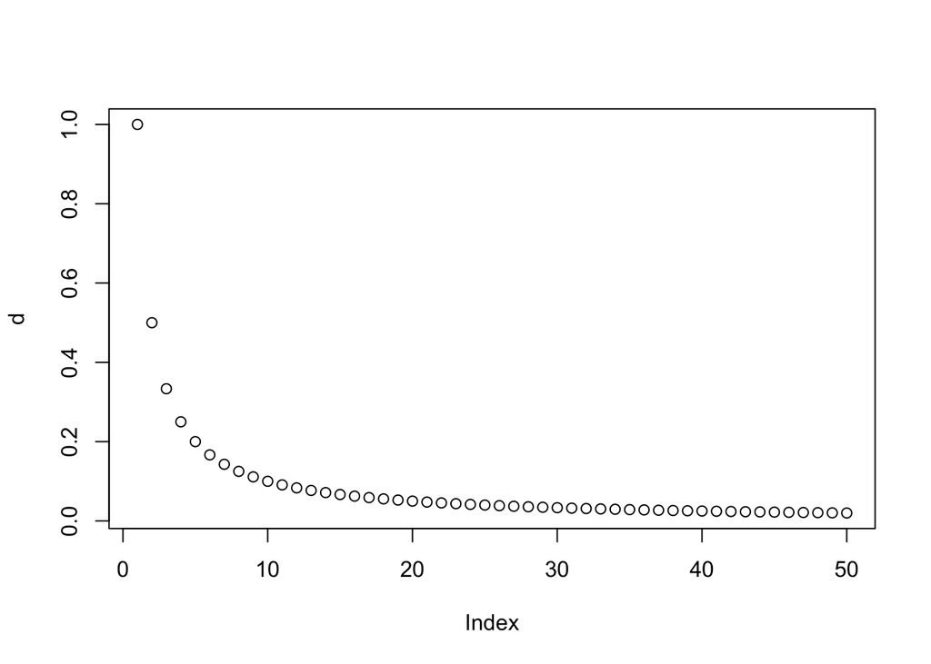

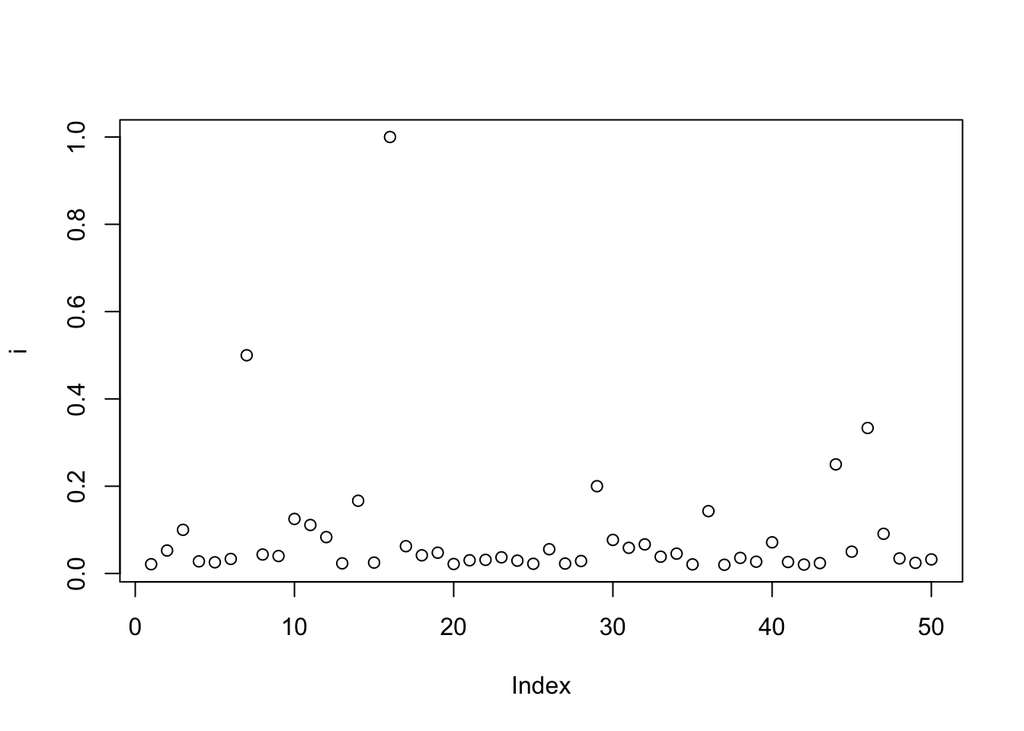

```r
plot(d)
```

```r
plot(i)
```

Visually it is obvious that `d` has dependent observations whereas `i` seems random.

There plots are called run charts, or *run-sequence plots*, they display observed data in a time sequence.

A run-sequence chart can uncover obvious dependence in the data.

## Lag plots

Another technique to uncover dependence is to use **lag plots**.

A lag plot checks whether there is dependence between pairs of observations by plotting the current value against a previous value.

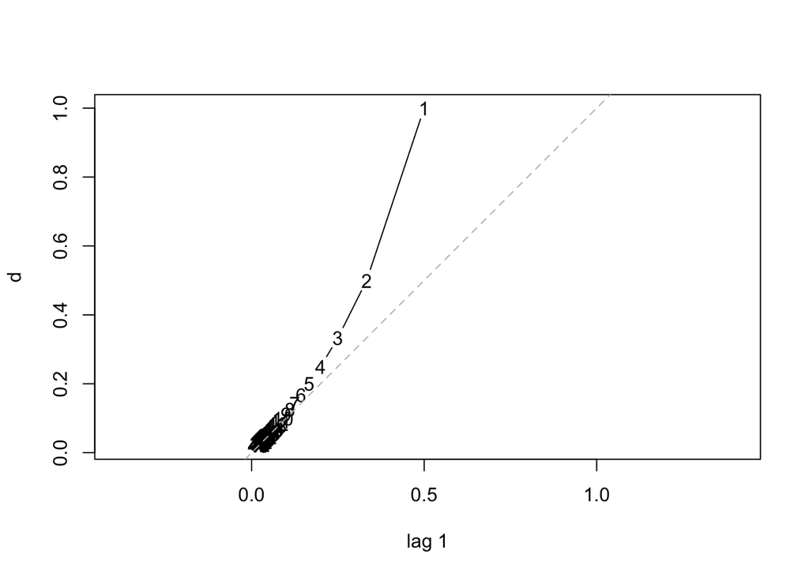

```r
lag.plot(d)
```

The x axis is `d[i+1]`, the y axis shows `d[i]`.

Independent data should have no clear structure. It should be roughly symmetrical over the diagonal.

The following lag plot for th `i` does not have structure.

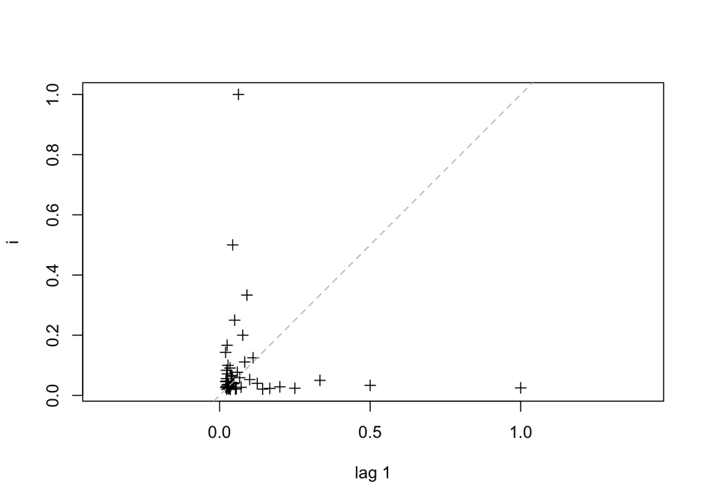

```r
lag.plot(i,
         do.lines=F, # don't draw lines
         labels=F,   # don't put labels
         pch=3)      # use crosses for points
```

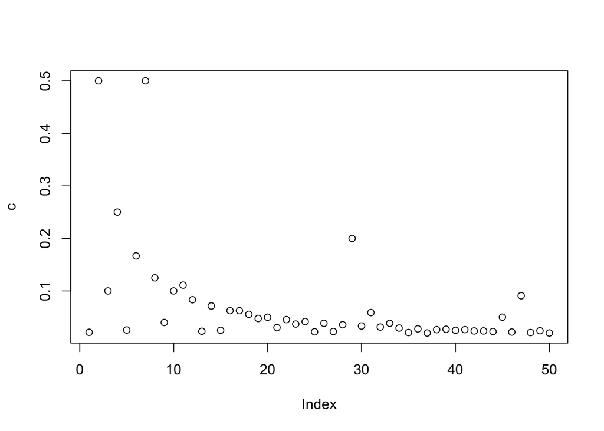

```r
c <- d
c[c(T,F)] <- i[c(T,F)]

plot(c)
```

The lag plot with a lag of one does not show dependence.

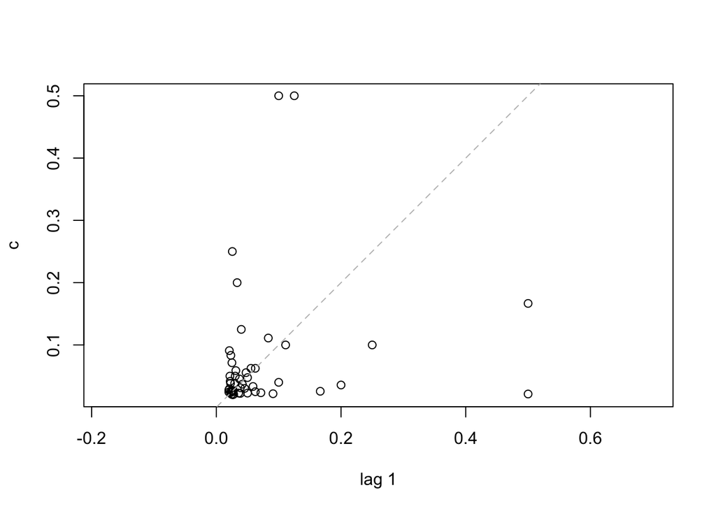

```r
lag.plot(c, labels=F,do.lines=F)
```

With a lag of 2 a little more structure can be observed.

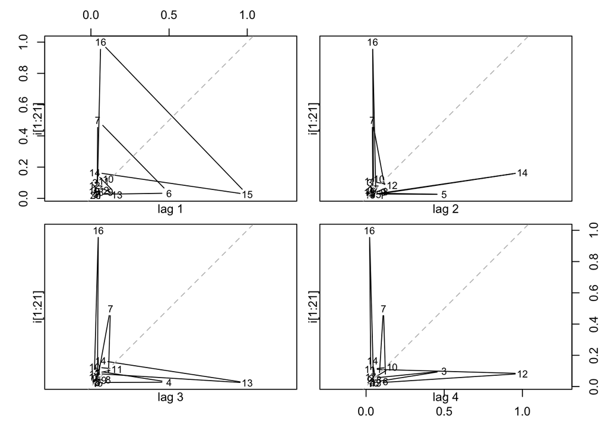

```r
lag.plot(i[1:21], lags=4)
```

## Auto-correlation function

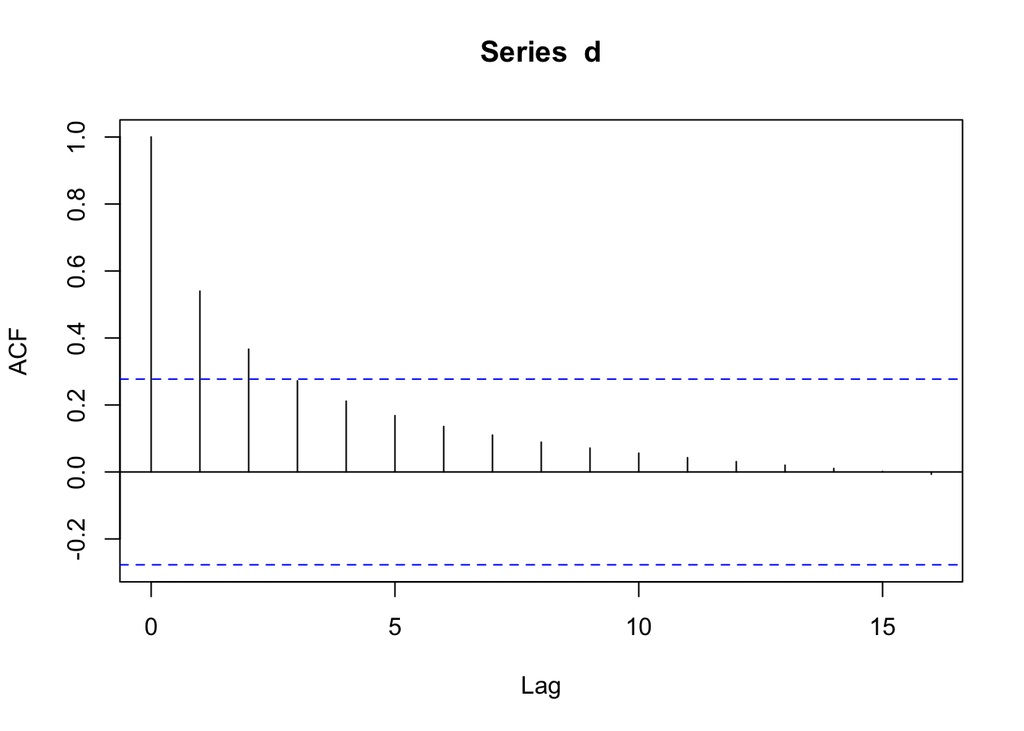

```r
acf(d)
```

The auto correlation function compute the correlation between points separated by various time lags.

Details at https://en.wikipedia.org/wiki/Auto correlation

${\hat {R}}(k)={\frac {1}{(n-k)\sigma ^{2}}}\sum _{t=1}^{n-k}(X_{t}-\mu )(X_{t+k}-\mu )$

There is a clear correlation at lag 1, and 2.

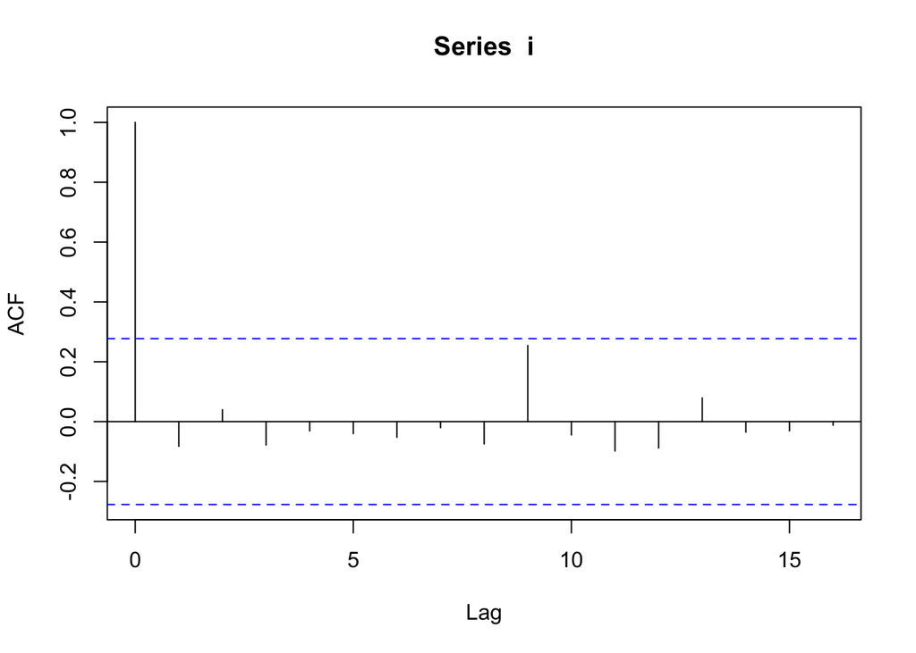

```r
acf(i)
```

The blue line is marks the auto-correlation of white noise.

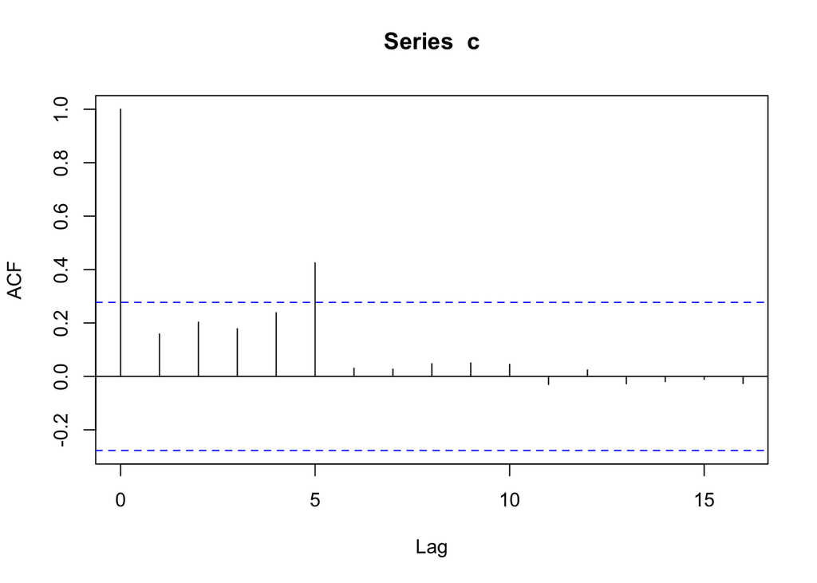

```r
acf(c)
```

# Use-case 3: FFT benchmark

This use-case investigates the FFT benchmark; a fast Fourier transform (FFT) algorithm computes the discrete Fourier transform of a sequence. The FFT benchmark is run by a harness which controls multiple iterations of the benchmark. We also do multiple runs of the benchmark.

## Import

We do 100 runs of the FFT benchmark and for each run we have 2048 iterations taken on an Itanium operating at a clock rate of 800.179008 MHz. Each run is stored in one file.

```r
read_bench <- function(name, n)  read.table(paste(name, n, ".out", sep=""), header=T)
read_fft <- function(n)  read_bench("fft_ia64/run", n)
summary(read_fft(1))
```

```
##    CPU_CYCLES          L2_MISSES         L3_MISSES        DTLB_MISSES
##  Min.   :452007807   Min.   :7618733   Min.   :2262200   Min.   :1460
##  1st Qu.:452343539   1st Qu.:7620333   1st Qu.:2263688   1st Qu.:1505
##  Median :454096030   Median :7620598   Median :2264114   Median :1521
##  Mean   :453519842   Mean   :7620600   Mean   :2264164   Mean   :1520
##  3rd Qu.:454212613   3rd Qu.:7620846   3rd Qu.:2264620   3rd Qu.:1535
##  Max.   :454791220   Max.   :7622430   Max.   :2269118   Max.   :1591
```

The data consists of four columns with processor-level information. A peek at the raw data gives the following.

```r
read_fft(1)[1:10,]
```

```
##    CPU_CYCLES L2_MISSES L3_MISSES DTLB_MISSES
## 1   452285121   7620440   2264388        1517
## 2   452118905   7620353   2263571        1540
## 3   452167993   7621180   2264087        1493
## 4   452278033   7620822   2264624        1551
## 5   452156488   7621053   2264707        1533
## 6   452190926   7620082   2263947        1485
## 7   452220682   7620661   2264364        1509
## 8   452165291   7619568   2263693        1507
## 9   452251504   7621264   2264071        1512
## 10  452208576   7620303   2264408        1557
```

Since we are interested in an ends-based, lets read all data files, select CPU_CYCLES, merge data to a single long vector and scale the measurement to seconds by dividing the cycles by the clock rate of the processor.

```r
runs <- lapply(1:100, function(n) (read_fft(n))[["CPU_CYCLES"]] )
ia64 <- Reduce(c, runs)
ia64 <- ia64/(800.179008*1e6)
ia64[1:10]
```

```
##  [1] 0.5652299 0.5650222 0.5650835 0.5652211 0.5650692 0.5651122 0.5651494
##  [8] 0.5650802 0.5651879 0.5651343
```

## Analysis

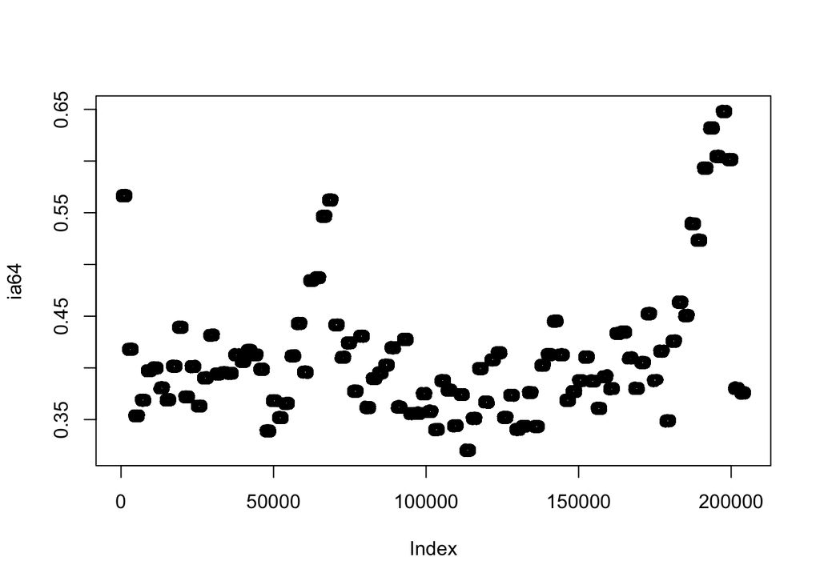

```r
Fast(plot(ia64))
```

The number of observations makes it hard to see what is going here, let’s zoom in on the first five runs.

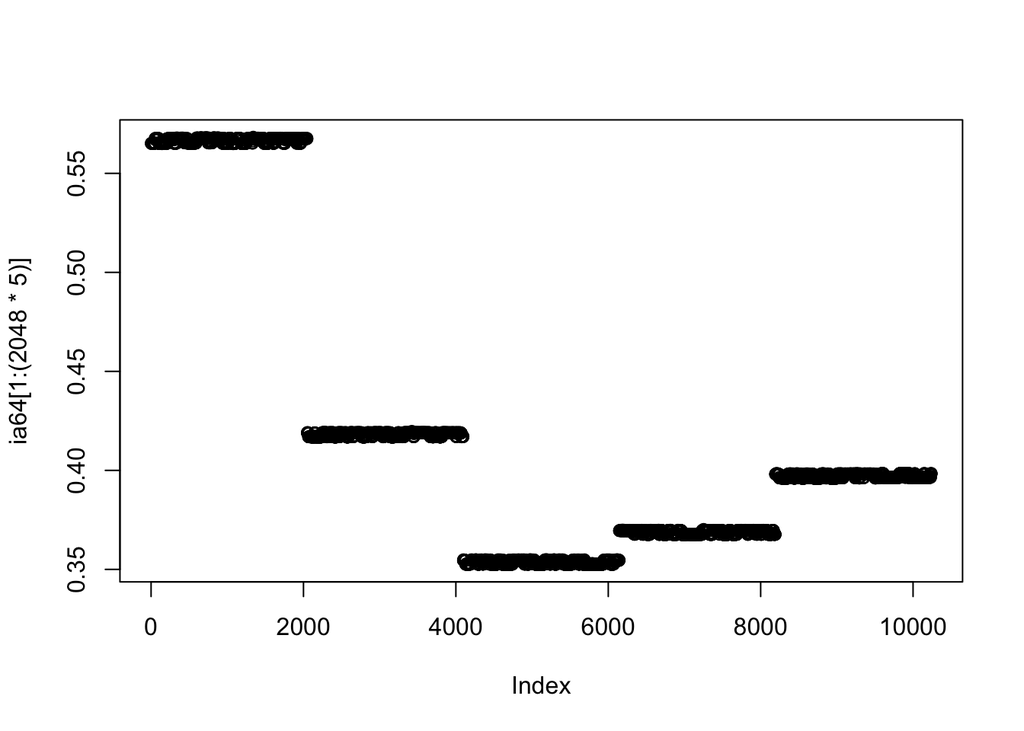

```r
plot(ia64[1:(2048*5)])
```

Clearly non-determinism affects the runs of the benchmark. So we must increase the number of runs, on the other hand each run can have fewer iterations.

We plot all of the data at hand to see if an explanation for the inter-run variance can be found.

There is an obvious correlation between CPU_CYCLES an L3 cache misses.

L3 cache: A memory bank built onto the motherboard or within the CPU module. The L3 cache feeds the L2 cache, and its memory is typically slower than the L2 memory, but faster than main memory. The L3 cache feeds the L2 cache, which feeds the L1 cache, which feeds the processor. The TLB stores the recent translations of virtual memory to physical memory and can be called an address-translation cache.

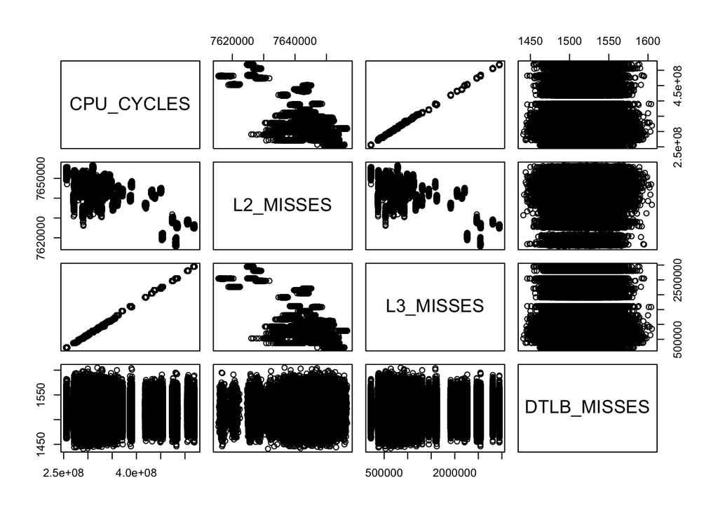

```r
runs <- lapply(1:100, function(n) read_bench("fft_ia64/run", n))
ia64 <- Reduce(rbind, runs)
Fast(plot(ia64))
```

[output not shown]

## Build-level non-determinism

Non-determinism can show up in the process of building or deploying a system. For example, if the compiler has some non-determinism, all runs and all iterations of a particular executable will be affected. In that case, it is necessary recompile the program before each iteration of the experiment.

Examples include: on some systems the order in which the compiled files are given to the linker may impact performance (e.g. SPECCPU, training size). This is a fixed effect (all runs will feel it) that can be controlled. You can randomize the linking order (or anything else that affects performance) and repeat compilation. The challenge is knowing what to control for. On some systems, build is non-deterministic, e.g. C++ compiler implementing anonymous namespaces. There, the only way is compile many times.

The following plot show Mono .Net compilation data. There are clear patterns. Performance seems to be tiered.

[figure not shown]

## Apparté: Builds vs Runs vs Iterations?

Find the highest level of non-determinism in the system: i.e. builds, runs or iterations. Identify important uncontrolled fixed effects and randomize them (like linking order, code layout). Check if building is deterministic, binaries have different performance. If runs are cheap, have multiple runs, otherwise multiple iterations.

## USE-CASE 4: FFT on P4

Spotting non-determinism in an experiment can sometimes be done by visual inspection of scatter plots of the original data compared to sampled data. The difference is apparent if the original data has structure whereas the sampled data does not.

Consider the following data set where we measured the FFT benchmark running on a P4 processor. The same data is sampled and plotted. The scatter plot makes the issue quite clear, points are clustered in runs.

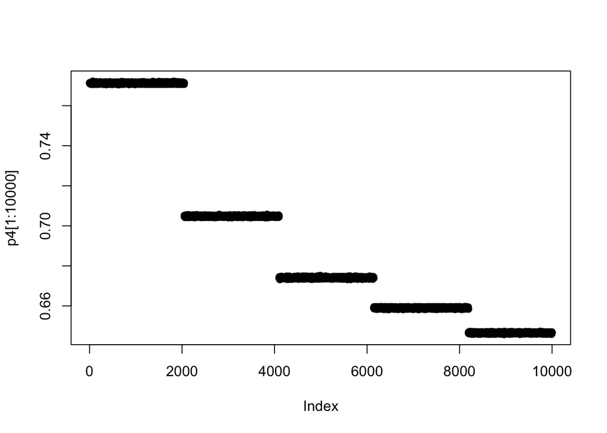

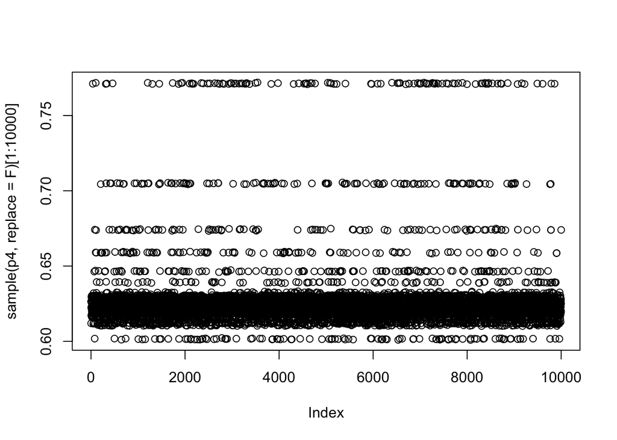

```r
runs4 <- lapply(1:100, function(n) read_bench("fft_p4/run", n)[["tsc"]])
p4 <- Reduce(c, runs4)
p4 <- p4/(2194.055*1e6)
plot(p4[1:10000])
```

```r
plot(sample(p4, replace=F)[1:10000])
```

But, what if visual inspection is inconclusive? We can also compare variances (variance estimates) for iterations in the same execution and iterations in different executions.

*Variance* Var(X) is a measure of dispersion/spread of random variable, “mean square distance from the expectation”. It is computed with `var(x)`. *Standard deviation* sd(X) is square root of the variance (so in units of variable X). *Coefficient of variation* (COV) is standard deviation divided by the mean (aka variation, relative variation, sometimes given as percentage). They are computed, respectively, with `sd(x)` and `sd(x)/means(x)`.

```r
x <- read_bench("fft_p4/run",1)$tsc
sd(x)/mean(x)
```

```
## [1] 0.0003345541
```

```r
r <- sapply(1:100, function(n) read_bench("fft_p4/run", n)$tsc[1])
sd(r)/mean(r)
```

```
## [1] 0.03017004
```

In many cases the difference in variations is not this obvious.

A sophisticated method for comparing variations is ANOVA (analysis of variance), but it has its own assumptions, and only focuses on variance.

# USE-CASE 5: Dacapo Warmup

Another instance of data that is not independent comes from the warmup that many computer systems experience By warmup we mean that the system has two (at least) distinct modes of execution or two phases: the **warmup** and the **steady state**.

Typically warmup is characterized by slower execution time and greater variability. When steady state is reached, the executions are typically more predictable and faster.

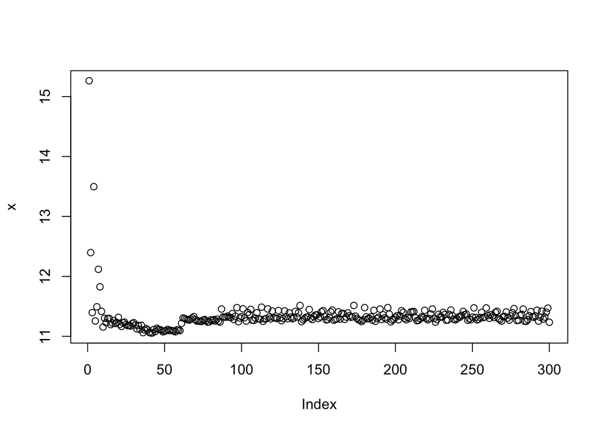

[figure not shown]

```r
read_Dacapo <- function(fn) {
  out <- readLines(fn)
  rlines <- grep("==== DaCapo .* in [0-9]+ msec.*", out, val=T)
  timesms <- as.numeric(gsub(".* in ([0-9]+) msec.*","\\1",rlines))
  timesms / 1000
}
x <- read_Dacapo("dacapo/chart6/chart6_1_1.out")
plot(x)
```

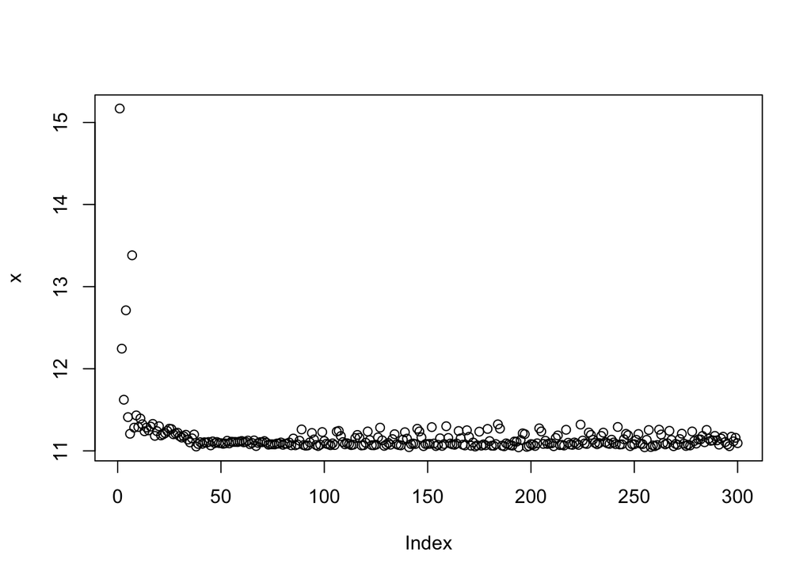

```r
x <- read_Dacapo("dacapo/chart6/chart6_2_1.out")
plot(x)
```

```r
x <- read_Dacapo("dacapo/chart6/chart6_3_1.out")
plot(x)
```

During the warmup phase data is not independent. What we must do then, is to identify how many iterations/runs are affected by the system initialization. One good way to do so is to use run-sequence plots at different scales and validate our observation by repeating the experiment.

The goal is to find the point where the data becomes independent, as only independent data can be used for summarization (e.g. to compute a confidence interval).

Of course, it is possible that in some systems there is no steady state and that data remains dependent.

To sum up if there is warmup across iterations, do more runs, if there is warmup across runs, repeat experiment.

There are frameworks that attempt to automatically detect when data reach steady state, but this is still a research problem and they have been shown to not be accurate (they do not always detect the end of warmup or independence).

# USE-CASE 6: The Java Dacapo Benchmark suite

How to report on the performance of a system across multiple benchmarks? We can’t use a single mean to summarize them all, as they are incomparable individually. Instead, we can summarize them with a bar plot.

## Import

The `dacapo` directory contains one sub-directory per benchmark, and, in each, one file per run.

```r
list_out_files <- function(bench)  list.files(paste("dacapo", bench, sep="/"), pattern="*.out")

read_dacapo_bench <- function(bench)
   sum(
     sapply( list_out_files(bench),
            function(f) sum(read_Dacapo(paste("dacapo", bench, f, sep="/")))))


st <-sapply(list.files("dacapo"), read_dacapo_bench)
st
```

```
##      antlr6     avrora9      batik9      bloat6      chart6    eclipse6
##    2086.023   31512.739       0.000   30935.079   10071.882   46670.827
##    eclipse9        fop6        fop9         h29     hsqldb6     jython6
##  139816.574    1600.225     371.991   65926.796    5501.118   30518.307
##     jython9    luindex6    luindex9   lusearch6   lusearch9        pmd6
##   31500.640    4985.292    1061.885     399.864    1750.925    9769.739
##        pmd9    sunflow9     tomcat9 tradebeans9  tradesoap9      xalan6
##    4279.165    1887.165    2228.725   45226.676   19466.862   10218.108
##      xalan9
##    5987.038
```

## Plotting total time

Now let’s plot it with ggplot.

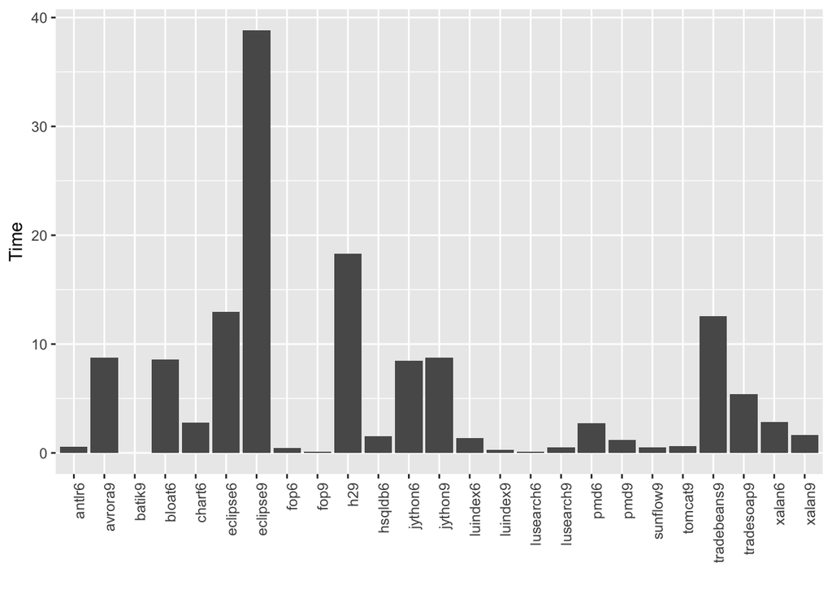

```r
df <- data.frame( Time=round(st/3600,3))

ggplot(df)  +
  geom_bar(mapping = aes(x=rownames(df), y=Time), stat="identity") +
  xlab("") +
  theme(axis.text.x = element_text(angle = 90, hjust = 1))
```

# USE-CASE 7: AST vs BC

In this last use-case we will look at data for performance of two versions of the R interpreter on a suite of benchmarks programs. This is an ends-based study. We want to know if the ast interpreter (AST) is faster or slower than the bytecode interpreter (BC).

## Data import

```r
ast <- as.matrix(read.table("ast.out", row.names=1))
bc <- as.matrix(read.table("bc.out", row.names=1))
ast
```

```
##                              V2      V3      V4      V5      V6      V7
## binarytrees-2           159.515 159.977 159.037 159.252 159.182 159.372
## binarytrees             154.135 155.531 154.372 154.342 153.849 154.509
## binarytrees-naive       158.444 158.291 158.621 158.509 158.781 158.548
## fannkuchredux           194.860 194.301 192.512 193.750 192.590 193.729
## fannkuchredux-naive     366.592 367.259 365.851 370.273 367.268 368.066
## fasta-2                 123.502 123.760 123.016 122.244 122.307 124.510
## fasta-3                 122.674 121.570 123.969 122.513 121.018 123.325
## fasta                   118.835 116.978 117.280 116.372 118.042 118.637
## fasta-naive2            236.182 232.127 231.673 230.933 234.934 231.853
## fasta-naive             190.525 190.008 191.731 189.524 189.293 190.734
## fastaredux              162.813 159.815 162.012 159.796 160.398 163.539
## fastaredux-naive        187.349 180.503 186.194 181.380 181.463 183.681
## knucleotide-brute2       77.387  77.076  76.678  76.661  76.740  77.619
## knucleotide-brute3       63.246  62.911  63.331  63.060  62.958  63.174
## knucleotide-brute        75.377  75.162  75.421  75.213  75.567  75.570
## knucleotide              83.934  83.220  83.572  83.729  85.490  75.541
## mandelbrot               65.915  65.679  65.602  65.667  65.396  65.596
## mandelbrot-naive        228.185 224.450 224.993 225.028 225.365 229.599
## mandelbrot-noout         66.947  67.156  67.165  66.962  67.272  67.211
## mandelbrot-noout-naive   70.336  70.521  70.635  70.562  70.544  73.981
## nbody-2                 101.526 101.475 101.500 101.859 102.118 101.849
## nbody-3                  99.970 100.334 101.420  98.711  99.131 100.963
## nbody                    73.873  74.028  72.967  72.952  74.530  74.264
## nbody-naive2            136.444 137.180 135.333 136.704 136.267 136.575
## nbody-naive             235.812 236.927 236.860 238.065 236.355 238.844
## pidigits                107.363 107.147 107.126 106.463 107.273 106.165
## regexdna                 73.561  73.373  73.222  73.234  73.322  74.337
## reversecomplement-2      75.387  75.487  77.938  75.384  76.896  77.280
## reversecomplement        69.414  69.099  68.993  68.808  68.609  70.010
## reversecomplement-naive 136.748 137.481 137.947 137.740 136.912 141.625
## spectralnorm-alt2        91.710  91.803  92.116  91.807  91.983  99.726
## spectralnorm-alt3       133.986 134.123 137.243 135.001 135.022 139.267
## spectralnorm-alt4       152.842 152.574 152.096 152.837 152.121 154.474
## spectralnorm-alt         63.992  64.092  64.097  64.098  64.106  64.762
## spectralnorm            271.536 270.852 271.110 270.191 276.521 274.882
## spectralnorm-math        80.641  80.918  80.955  81.026  80.979  81.112
## spectralnorm-naive      246.660 243.853 246.185 248.875 245.244 247.683
##                              V8      V9     V10     V11
## binarytrees-2           159.372 159.136 159.721 159.528
```

[output cut: 21 more lines]

```
## nbody                    75.000  74.821  74.497  75.729
## nbody-naive2            136.112 136.802 136.449 136.073
## nbody-naive             238.523 237.807 237.651 238.556
## pidigits                105.828 105.435 104.491 105.240
## regexdna                 73.858  75.598  73.812  73.847
## reversecomplement-2      76.083  76.846  75.563  77.084
## reversecomplement        70.145  69.526  70.812  70.269
## reversecomplement-naive 139.463 139.496 140.842 140.685
## spectralnorm-alt2        99.848  99.481  99.346  99.458
## spectralnorm-alt3       137.383 138.098 138.036 137.781
## spectralnorm-alt4       154.248 154.334 154.487 155.732
## spectralnorm-alt         64.625  64.585  64.634  64.645
## spectralnorm            274.235 275.948 273.433 273.790
## spectralnorm-math        81.407  81.562  81.430  81.506
## spectralnorm-naive      249.027 247.990 250.043 246.100
```

## Summarizing performance difference for one benchmark.

Let’s pick one benchmark randomly, “pidigits”, and report the speedup of bc over ast. Here ast is the old system and bc is the new, so we computer old/new.

```r
mean(ast["pidigits",]/bc["pidigits",])
```

```
## [1] 1.691204
```

It would be better to compute a confidence interval.

```r
pidata <- data.frame(new=bc["pidigits",], old=ast["pidigits",])

f <- function(d, sel) mean(d[sel,"old"])/mean(d[sel,"new"])

b <- boot(pidata, f, R=1000)
ci <- boot.ci(b, conf=0.95, type="perc")
ci
```

```
## BOOTSTRAP CONFIDENCE INTERVAL CALCULATIONS
## Based on 1000 bootstrap replicates
##
## CALL :
## boot.ci(boot.out = b, conf = 0.95, type = "perc")
##
## Intervals :
## Level     Percentile
## 95%   ( 1.684,  1.699 )
## Calculations and Intervals on Original Scale
```

With 95% confidence, the BC is between 1.68x and 1.70x faster than AST when running the pidigits benchmark.

## Summarizing multiple benchmarks

Barplot for the speedup of BC over AST, with confidence intervals for the ratio of means.

```r
# df_row_mean: DataFrame x [Num] -> [Num]
# Return the ration of the mean
df_row_mean <- function(df, sel) mean(df[sel,"old"]) / mean(df[sel, "new"])

# cfratio: Num x Num -> result is [Num, Num]
# Returns result which is a pair of numbers
cfratio <- function(oldvec, newvec) {
  df <- data.frame(old=oldvec, new=newvec)
  b <- boot(df, df_row_mean, R=1000)
  ci <- boot.ci(b, conf=0.95, type="perc")
  ci$perc[4:5] # low, hi
}


cfratios <- function(old, new) { # old/new - matrices benchmarks x times
  m <- sapply(rownames(old), function(b) {
    o <- old[b,]
    n <- new[b,]
    c(cfratio(o,n), mean(o)/mean(n))
  })
 rownames(m) <- c("low", "hi", "meansRatio")
 t(m) # matrix benchmarks x c("low", "hi", "meansRatio")
}
```

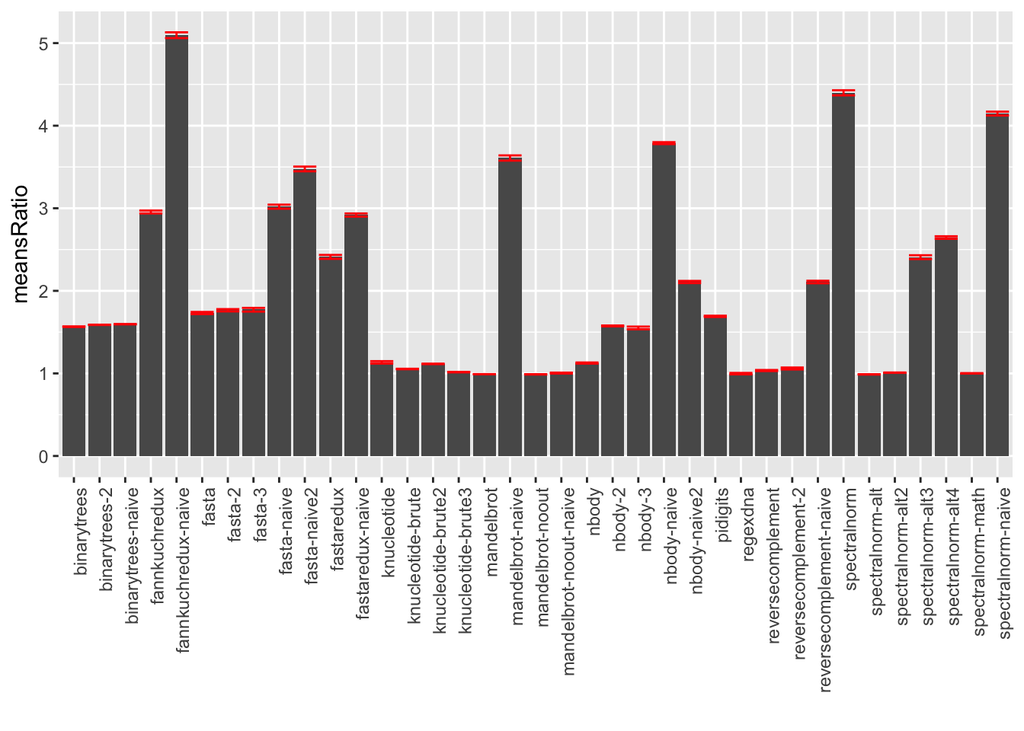

```r
df <-as.data.frame( cfratios(ast, bc))

ggplot(df, aes(x=row.names(df), y=meansRatio)) +
  geom_bar(position=position_dodge(), stat="identity") +
  geom_errorbar(aes(ymin=low, ymax=hi), position=position_dodge(),
      colour="red") +
  xlab("") +
  theme(axis.text.x = element_text(angle=90, hjust=1) )
```

More to talk about: p-values, t-test, discuss geometric mean, …